# Just Enough Statistics

## Disclaimer

- We can’t teach all of statistics in one hour.
- Many of the examples here are not strictly correct, but are used to demonstrate a point.

## Before we start… We need some fake ages

```r
library(tidyverse)
RCT <- read.csv("http://bit.ly/2XzvW47")
```

# The big picture

## Statistics

- We aspire to discern some truth from the universe.
- We take measurements, but cannot measure all patients in a *population*.
- Therefore we have to take a *sample*, and take measurements from this sample.
- We then apply mathematical functions on these raw measurements to try and discern truth.
- *f(raw measurements) -> Statistics*

## Our RCT using this analogy

- Our RCT attempts to answer a research question by collecting data from a *sample* of a *population*.
- Data collection consists in measuring the values of several *variables* for each member of the sample.

# Statistics broadly classified

## Descriptive statistics

- Describe the central tendencies
- Describe the spread
- Describe the proportions
- Summarise the data

## Inferential statistics

- Deduce conclusions about the population from the sample
- Test the reliability of those conclusions

## Variables

- Variables may be *continuous* or *discrete*
- Consider these:
  - **age**
  - **random**, **satisfaction**

# Descriptive Statistics

## Distributions

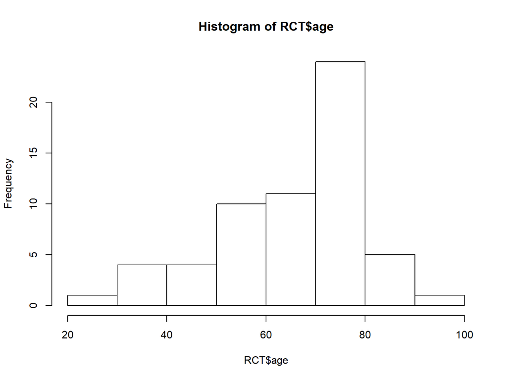

```r
hist(RCT$age)
```

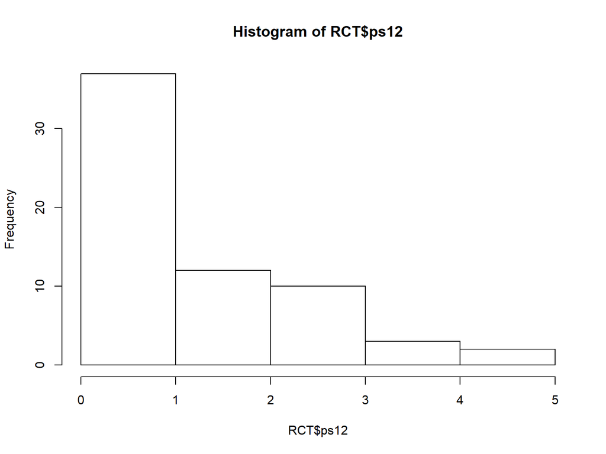

```r
hist(RCT$ps12)
```

## Do our variables looks like this?

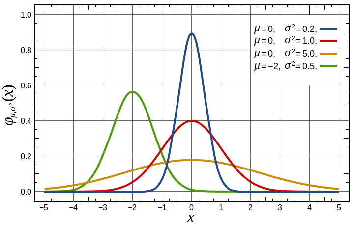

## Means, medians and modes

- Mean: sum of all datapoints / number of datapoints
- Median: middle datapoint
- Mode: most common datapoint

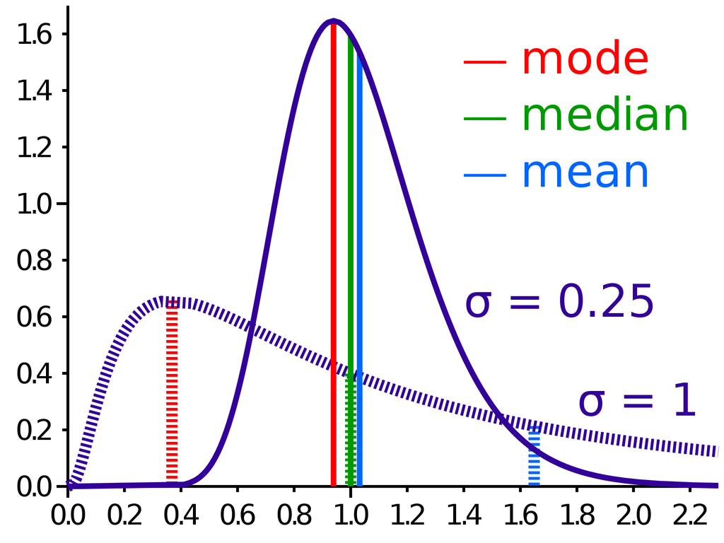

Have a go with these variables: **age**, **ps12**, **move24h**

## Have a go

- You can use the functions `mean()` and `median()`, for example:

```r
mean(RCT$ps12, na.rm = TRUE)
```

```
## [1] 1.40625
```

```r
median(RCT$ps12, na.rm = TRUE)
```

```
## [1] 1
```

## Measuring ‘spread’

- For normally distibuted data, use standard deviation
- For non-normally distributed data, use interquartile range

```r
IQR(RCT$age, na.rm = TRUE)
```

```
## [1] 22
```

```r
quantile(RCT$age, na.rm = TRUE, probs = c(0.25, 0.75))
```

```
## 25% 75%
##  55  77
```

```r
sd(RCT$age, na.rm = TRUE)
```

```
## [1] 14.55191
```

## Calculate it all at once

```r
summary(RCT)
```

```
##        X               id             recruit        age        gender
##  Min.   : 0.00   Min.   : 1.00   1/1/2014 : 1   Min.   :29.00   f:25
##  1st Qu.:15.75   1st Qu.:16.75   1/10/2014: 1   1st Qu.:55.00   F:38
##  Median :31.50   Median :32.50   1/11/2014: 1   Median :70.50   M: 1
##  Mean   :31.50   Mean   :32.50   1/12/2014: 1   Mean   :66.27
##  3rd Qu.:47.25   3rd Qu.:48.25   1/13/2014: 1   3rd Qu.:77.00
##  Max.   :63.00   Max.   :64.00   1/14/2014: 1   Max.   :95.00
##                                  (Other)  :58   NA's   :4
##    random        ps0h             ps3h            ps12
##  drain:35   Min.   :0.0000   Min.   :0.000   Min.   :0.000
##  skin :29   1st Qu.:0.0000   1st Qu.:0.000   1st Qu.:0.000
##             Median :0.0000   Median :1.000   Median :1.000
##             Mean   :0.1905   Mean   :1.125   Mean   :1.406
##             3rd Qu.:0.0000   3rd Qu.:2.000   3rd Qu.:2.000
##             Max.   :3.0000   Max.   :5.000   Max.   :5.000
##             NA's   :1
##      ps24h          ps168h          move12h         move24h
##  Min.   :0.00   Min.   :0.0000   Min.   :0.000   Min.   :0.0000
##  1st Qu.:0.00   1st Qu.:0.0000   1st Qu.:0.000   1st Qu.:0.0000
##  Median :1.00   Median :0.0000   Median :1.000   Median :1.0000
##  Mean   :1.25   Mean   :0.6275   Mean   :1.078   Mean   :0.9375
##  3rd Qu.:2.00   3rd Qu.:1.0000   3rd Qu.:2.000   3rd Qu.:1.2500
##  Max.   :5.00   Max.   :3.0000   Max.   :5.000   Max.   :5.0000
##                 NA's   :13
##     move168h         tylenol    codeine      oramorph
##  Min.   :0.0000   8g     :31   0    :56   0      :47
##  1st Qu.:0.0000   4g     :15   10mg : 1   10mg   : 7
##  Median :0.0000   0      : 5   120mg: 1   20mg   : 4
##  Mean   :0.6078   2g     : 4   210mg: 1   50mg   : 2
##  3rd Qu.:1.0000   3g     : 3   30mg : 1   30mg   : 1
##  Max.   :4.0000   1g     : 2   60mg : 4   5mg    : 1
##  NA's   :13       (Other): 4              (Other): 2
##               other         los
##  0               :34   Min.   : 0.000
##  Diclofenac 225mg:10   1st Qu.: 2.000
##  Diclofenac 300mg: 2   Median : 3.000
##  Diclofenac 75mg : 2   Mean   : 3.431
##  Ibuprofen 800mg : 2   3rd Qu.: 4.000
##  Morphine 20mg   : 2   Max.   :10.000
##  (Other)         :12   NA's   :13
##                                           los_reason       satisfaction
##                                                :12               :12
##  Comorbidities- recurrent PE                   : 2   Excellent   :13
##  Continued fluid through drain                 :47   Good        :29
##  Continued fluid through drain and bowel stasis: 1   Poor        : 3
##  Pain due to spinal mets                       : 1   satisfactory: 6
##  Urinary incontinence                          : 1   Satisfactory: 1
##
##     fake_age     binary_satisfaction
##  Min.   :43.98   Min.   :0.0000
##  1st Qu.:63.13   1st Qu.:0.0000
##  Median :76.99   Median :1.0000
##  Mean   :73.49   Mean   :0.6562
##  3rd Qu.:83.01   3rd Qu.:1.0000
##  Max.   :92.50   Max.   :1.0000
##
```

## Inferential statistics

## Testing (here be dragons)

- best_option <- “**Ask a statistician**”
- pragmatic_option <- “Do it yourself, **carefully** and **simply**”

## Think about

1. The hypothesis you want to test
2. Where your observations come from
3. The type of variables you are dealing with
4. The assumptions that different tests use
5. Interpreting the test results

## Hypothesis 1

> ‘Mean age differs between the two treatment arms’
- What sort of variables are these?
- What is the *independent variable*?
- What is the *dependent variable*?
- What is the *null hypothesis*?
- **Which test should we use?**

## Unpaired t-test: Assumptions

- Values within each group are independent
- The two groups are independent of one another
- (Values in each group should be approximately normally-distributed)

## Let’s look at our data…

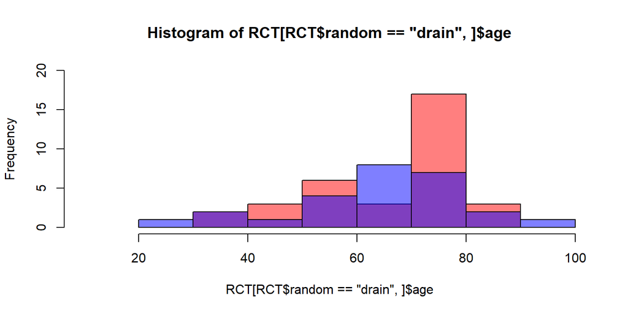

```r
hist(RCT[RCT$random == "drain", ]$age, , xlim=c(10, 100), ylim=c(0, 20), col = "#FF000080")
hist(RCT[RCT$random == "skin", ]$age, col = "#0000FF80", add = TRUE)
```

- Because we don’t really have differences in age, we needed to create some fake data.

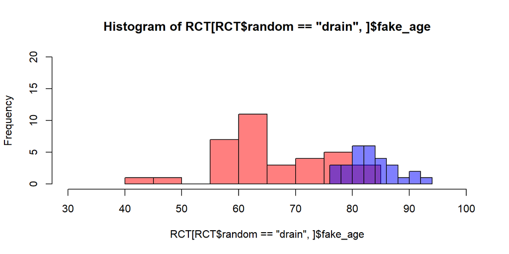

```r
hist(RCT[RCT$random == "drain", ]$fake_age, xlim=c(30, 100), ylim=c(0, 20), col = "#FF000080")
hist(RCT[RCT$random == "skin", ]$fake_age, col = "#0000FF80", add = TRUE)
```

## Let’s run the test!

- Note that the ‘spread’ of the groups is different - a problem for the standard t test, but R takes care of this for us behind the scenes (it gives us Welch’s instead of Student’s t-test).

```r
t.test(RCT$fake_age ~ RCT$random)
```

```
##
##  Welch Two Sample t-test
##
## data:  RCT$fake_age by RCT$random
## t = -9.6394, df = 48.021, p-value = 8.275e-13
## alternative hypothesis: true difference in means is not equal to 0
## 95 percent confidence interval:
##  -21.19970 -13.88222
## sample estimates:
## mean in group drain  mean in group skin
##            65.54566            83.08662
```

## Hypothesis 2

> ‘Patient satisfaction after axillary node dissection depends on treatment arm.’

## Hypothesis 2

> ‘Patient satisfaction after axillary node dissection depends on treatment arm.’
- What sort of variables are these?
- What is the *independent variable*?
- What is the *dependent variable*?
- What is the *null hypothesis*?
- **Which test should we use?**

## Chi-squared test for independence: Assumptions

- The two groups are independent of one another
- Count in each cell of the table should be 5 or more

## Let’s look at our data

```r
tbl <- table(RCT$random, RCT$binary_satisfaction)

tbl
```

```
##
##          0  1
##   drain  8 27
##   skin  14 15
```

## Let’s run the test!

```r
chisq.test(tbl)
```

```
##
##  Pearson's Chi-squared test with Yates' continuity correction
##
## data:  tbl
## X-squared = 3.4854, df = 1, p-value = 0.06191
```

## Hypothesis 3

> ‘Postoperative pain scores at 12hrs depends on treatment arm.’

## Hypothesis 3

> ‘Postoperative pain scores at 12hrs depends on treatment arm.’
- What sort of variables are these?
- What is the *independent variable*?
- What is the *dependent variable*?
- What is the *null hypothesis*?
- **Which test should we use?**

## Mann-Whitney U test: Assumptions

- AKA Wilcoxon Rank Sum test
- Dependent variable is either continuous or ordinal
- Independent variable is categorical
- Observations in each group are independent
- Distributions of dependent variable in each group are the same

## Let’s run the test!

```r
wilcox.test(RCT$ps12 ~ RCT$random, conf.int = TRUE)
```

```
##
##  Wilcoxon rank sum test with continuity correction
##
## data:  RCT$ps12 by RCT$random
## W = 259, p-value = 0.0005341
## alternative hypothesis: true location shift is not equal to 0
## 95 percent confidence interval:
##  -1.9999351 -0.9999614
## sample estimates:
## difference in location
##              -1.000061
```

# Extending this further

## Table One

- Most research studies have Table 1 describing patient baseline characteristics

```r
install.packages(tableone)
```

```r
library(tableone)
CreateTableOne(data = RCT,
               vars = c("age", "ps0h", "los", "satisfaction"),
               strata = "random")
```

```
##                   Stratified by random
##                    drain         skin          p      test
##   n                   35            29
##   age (mean (sd))  67.50 (14.04) 64.65 (15.32)  0.458
##   ps0h (mean (sd))  0.09 (0.29)   0.31 (0.71)   0.101
##   los (mean (sd))   3.23 (1.55)   3.71 (2.15)   0.357
##   satisfaction (%)                              0.266
##                        4 (11.4)      8 (27.6)
##      Excellent         9 (25.7)      4 (13.8)
##      Good             18 (51.4)     11 (37.9)
##      Poor              1 ( 2.9)      2 ( 6.9)
##      satisfactory      2 ( 5.7)      4 (13.8)
##      Satisfactory      1 ( 2.9)      0 ( 0.0)
```

## Modelling

- Beyond hypothesis testing, modelling tries to explain the *data generation* process.
- R can be used for any number of regression models, e.g. linear regression

## Linear regression

- Do patients who have a higher pain score at 3hrs have a longer Length of Stay?

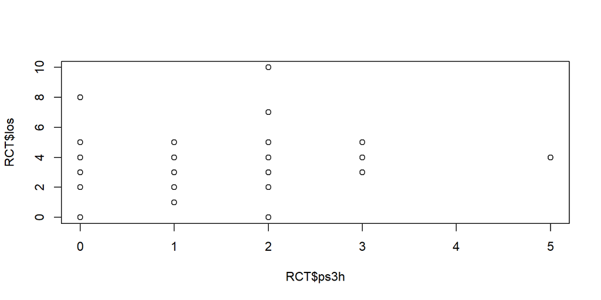

```r
plot(RCT$los ~ RCT$ps3h)
```

## Jittering for overplotting

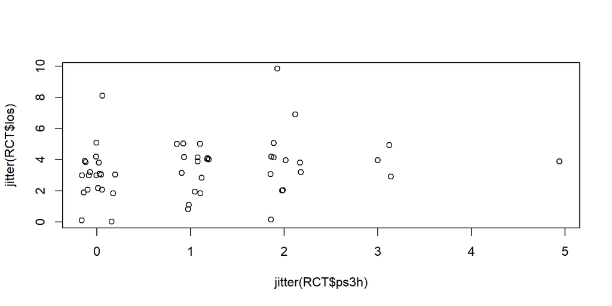

```r
plot(jitter(RCT$los) ~ jitter(RCT$ps3h))
```

```r
linear_model <- lm(los ~ ps3h, data = RCT)
summary(linear_model)
```

```
##
## Call:
## lm(formula = los ~ ps3h, data = RCT)
##
## Residuals:
##     Min      1Q  Median      3Q     Max
## -3.7703 -1.0648 -0.0648  0.7297  6.2297
##
## Coefficients:
##             Estimate Std. Error t value Pr(>|t|)
## (Intercept)   3.0648     0.3473   8.825 1.08e-11 ***
## ps3h          0.3527     0.2313   1.525    0.134
## ---
## Signif. codes:  0 '***' 0.001 '**' 0.01 '*' 0.05 '.' 0.1 ' ' 1
##
## Residual standard error: 1.79 on 49 degrees of freedom
##   (13 observations deleted due to missingness)
## Multiple R-squared:  0.04532,    Adjusted R-squared:  0.02584
## F-statistic: 2.326 on 1 and 49 DF,  p-value: 0.1336
```

## Logistic regression

- You might think that patients have different satisfaction levels by age

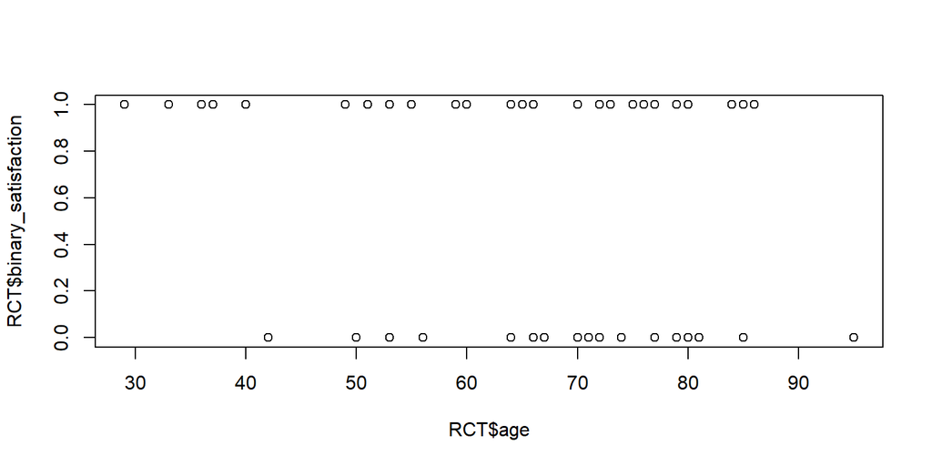

```r
plot(RCT$binary_satisfaction ~ RCT$age)
```

```r
logit_model <- glm(binary_satisfaction ~ age,
                   data = RCT,
                   family = binomial)
summary(logit_model)
```

```
##
## Call:
## glm(formula = binary_satisfaction ~ age, family = binomial, data = RCT)
##
## Deviance Residuals:
##     Min       1Q   Median       3Q      Max
## -1.7452  -1.3640   0.8001   0.9520   1.0715
##
## Coefficients:
##             Estimate Std. Error z value Pr(>|z|)
## (Intercept)  2.25316    1.41651   1.591    0.112
## age         -0.02324    0.02043  -1.138    0.255
##
## (Dispersion parameter for binomial family taken to be 1)
##
##     Null deviance: 76.382  on 59  degrees of freedom
## Residual deviance: 75.006  on 58  degrees of freedom
##   (4 observations deleted due to missingness)
## AIC: 79.006
##
## Number of Fisher Scoring iterations: 4
```

## Picking the right statistical tests

[UCLA Which test?](https://stats.idre.ucla.edu/other/mult-pkg/whatstat/)

## A gentle (and pretty!) intro to probability/stats

[Seeing theory](http://students.brown.edu/seeing-theory/)

## Statistical tests as Linear models

[Common statistical tests are linear models](https://lindeloev.github.io/tests-as-linear/)